# Análisis de PCA de precio y demanda de electricidad

Gabriel Cecconato

2024-07-16

# Descripción del análisis a realizar

El análisis de los componentes principales (*PCA, Principal Component Analysis*) es un método estadístico que utiliza autovalores y autovectores para convertir los conjuntos de observaciones a un conjunto de variables linealmente no correlacionadas, denominadas como **componentes principales**.

Se realiza para tomar un conjunto de datos de muchas dimensiones y reducir las mismas a un número más manejable, extraer las variables más importantes y encontrar aquellas que logran explicar la máxima variación en el conjunto de datos.

# Acerca del conjuntos de datos

El conjunto de datos contiene el precio diario, demanda y datos meteorológicos en el segundo estado más grande de Australia. El mismo es público y fue obtenido de https://www.kaggle.com/datasets/aramacus/electricity-demand-in-victoria-australia.

Según la fuente en 2020, 6,7 millones de personas residen en Victoria, el segundo estado más poblado de Australia. La mayoría de ellos, cinco millones, viven o trabajan en Melbourne, la capital del estado. Durante 2020, Australia fue uno de los primeros en cerrar fronteras internacionales, seguido de un cierre de fronteras interestatales. Victoria introdujo algunas de las restricciones más estrictas a la actividad empresarial relacionadas con la pandemia, lo que provocó que una parte importante de su población trabajara desde casa.

En el citado conjunto de datos hay 2106 observaciones y 14 variables, y su estructura es la siguiente:

```
## 'data.frame':    2106 obs. of  14 variables:
##  $ date           : chr  "2015-01-01" "2015-01-02" "2015-01-03" "2015-01-04" ...
##  $ demand         : num  99635 129606 142301 104331 118132 ...
##  $ RRP            : num  25.6 33.1 34.6 25 26.7 ...
##  $ demand_pos_RRP : num  97319 121082 142301 104331 118132 ...
##  $ RRP_positive   : num  26.4 38.8 34.6 25 26.7 ...
##  $ demand_neg_RRP : num  2316 8524 0 0 0 ...
##  $ RRP_negative   : num  -7.24 -47.81 0 0 0 ...
##  $ frac_at_neg_RRP: num  0.0208 0.0625 0 0 0 ...
##  $ min_temperature: num  13.3 15.4 20 16.3 15 17.7 18.9 23.1 16.5 13.6 ...
##  $ max_temperature: num  26.9 38.8 38.2 21.4 22 26 37.4 28.2 18 21.7 ...
##  $ solar_exposure : num  23.6 26.8 26.5 25.2 30.7 31.6 20.7 13.5 3.1 5.6 ...
##  $ rainfall       : num  0 0 0 4.2 0 0 0 19.4 1.2 5.2 ...
##  $ school_day     : chr  "N" "N" "N" "N" ...
##  $ holiday        : chr  "Y" "N" "N" "N" ...
```

## Descripción de las variables

1. **date**: fecha de la observación.
2. **demand**: demanda total diaria de electricidad en MWh.
3. **RRP**: precio de venta recomendado en AUD$/MWh.
4. **demand_pos_RRP**: demanda diaria total con un **RRP** positivo en MWh.
5. **RRP_positive**: **RRP** positivo promedio, ponderado por la demanda intradiaria correspondiente en AUD$/MWh.
6. **demand_neg_RRP**: demanda diaria total con un **RRP** negativo en MWh.
7. **RRP_negative**: **RRP** negativo promedio, ponderado por la demanda intradiaria correspondiente en AUD$/MWh.
8. **frac_at_neg_RRP**: una fracción del día en que la demanda se negoció a un **RRP** negativo.
9. **min_temperature**: temperatura mínima durante el día en grados Celsius.
10. **max_temperature**: temperatura máxima durante el día en grados Celsius.
11. **solar_exposure** : energía solar diaria total en MJ/m<sup>2</sup>.
12. **rainfall**: precipitación diaria en mm.
13. **school_day**: si los estudiantes estaban en la escuela ese día (Y=sí, N=no).
14. **holiday**: si el día era feriado estatal o nacional (Y=sí, N=no).

# Acondicionamiento del conjunto de datos

Puesto que para implementar el **PCA** el conjunto de datos debe cumplir con los requisitos de que todas las variables de las observacioens deben ser numéricas y que no haya datos faltantes, se realizará un acondicioamiento previo según se detalla seguidamente.

## Modificación de tipos de datos

Convertimos los tipos de datos de algunas variables del conjunto de datos. La variables **date**, **school_day** y **holiday** no son numéricas.

- Puesto que las obsrvaciones están por fecha, asignaremos el valor de **date** a los nombres de las observaciones (filas) del conjunto de datos, y luego la eliminaremos.
- En cuanto a las variables **school_day** y **holiday** las convertiremos a numéricas (asignando 1 para “Y” y 0 para “N”).

Así la estructura de datos queda:

```
## 'data.frame':    2106 obs. of  13 variables:
##  $ demand         : num  99635 129606 142301 104331 118132 ...
##  $ RRP            : num  25.6 33.1 34.6 25 26.7 ...
##  $ demand_pos_RRP : num  97319 121082 142301 104331 118132 ...
##  $ RRP_positive   : num  26.4 38.8 34.6 25 26.7 ...
##  $ demand_neg_RRP : num  2316 8524 0 0 0 ...
##  $ RRP_negative   : num  -7.24 -47.81 0 0 0 ...
##  $ frac_at_neg_RRP: num  0.0208 0.0625 0 0 0 ...
##  $ min_temperature: num  13.3 15.4 20 16.3 15 17.7 18.9 23.1 16.5 13.6 ...
##  $ max_temperature: num  26.9 38.8 38.2 21.4 22 26 37.4 28.2 18 21.7 ...
##  $ solar_exposure : num  23.6 26.8 26.5 25.2 30.7 31.6 20.7 13.5 3.1 5.6 ...
##  $ rainfall       : num  0 0 0 4.2 0 0 0 19.4 1.2 5.2 ...
##  $ school_day     : num  0 0 0 0 0 0 0 0 0 0 ...
##  $ holiday        : num  1 0 0 0 0 0 0 0 0 0 ...
```

Y la vista de las primeras filas del conjunto de datos así:

```
##               demand      RRP demand_pos_RRP RRP_positive demand_neg_RRP
## 2015-01-01  99635.03 25.63370       97319.24     26.41595       2315.790
## 2015-01-02 129606.01 33.13899      121082.01     38.83766       8523.995
## 2015-01-03 142300.54 34.56485      142300.54     34.56485          0.000
## 2015-01-04 104330.71 25.00556      104330.71     25.00556          0.000
## 2015-01-05 118132.20 26.72418      118132.20     26.72418          0.000
## 2015-01-06 130672.48 31.28231      130672.48     31.28231          0.000
##            RRP_negative frac_at_neg_RRP min_temperature max_temperature
## 2015-01-01     -7.24000      0.02083333            13.3            26.9
## 2015-01-02    -47.80978      0.06250000            15.4            38.8
## 2015-01-03      0.00000      0.00000000            20.0            38.2
## 2015-01-04      0.00000      0.00000000            16.3            21.4
## 2015-01-05      0.00000      0.00000000            15.0            22.0
## 2015-01-06      0.00000      0.00000000            17.7            26.0
##            solar_exposure rainfall school_day holiday
## 2015-01-01           23.6      0.0          0       1
## 2015-01-02           26.8      0.0          0       0
## 2015-01-03           26.5      0.0          0       0
## 2015-01-04           25.2      4.2          0       0
## 2015-01-05           30.7      0.0          0       0
## 2015-01-06           31.6      0.0          0       0
```

## Datos faltantes

Analizamos el conjunto de datos y encontramos 4 datos faltantes con la siguiente desagregación por variable:

```
##          demand             RRP  demand_pos_RRP    RRP_positive  demand_neg_RRP
##               0               0               0               0               0
##    RRP_negative frac_at_neg_RRP min_temperature max_temperature  solar_exposure
##               0               0               0               0               1
##        rainfall      school_day         holiday
##               3               0               0
```

Se realizará la imputación de los datos faltantes con su respectiva mediana:

```r
ds_edva_copy <- ds_edva_copy %>%
  mutate(solar_exposure =
         replace_na(solar_exposure, median(solar_exposure, na.rm = TRUE)),
         rainfall =
         replace_na(rainfall, median(rainfall, na.rm = TRUE)),
         )
```

Presentamos un resumen del conjunto de datos con métricas relevantes por cada variable. Y debido a la imputación de los datos faltantes ya implementada, no se observan datos faltantes para ninguna de las variables.

```r
# Hacemos un summary, con lapply que sale en formato de lista y se lee mejor
lapply(ds_edva_copy,summary)
```

```
## $demand
##    Min. 1st Qu.  Median    Mean 3rd Qu.    Max.
##   85094  109964  119586  120035  130436  170654
##
## $RRP
##     Min.  1st Qu.   Median     Mean  3rd Qu.     Max.
##   -6.076   38.707   66.597   76.080   95.075 4549.645
##
## $demand_pos_RRP
##    Min. 1st Qu.  Median    Mean 3rd Qu.    Max.
##   41988  109246  119148  119252  130119  170654
##
## $RRP_positive
##    Min. 1st Qu.  Median    Mean 3rd Qu.    Max.
##   13.57   39.12   66.87   76.55   95.13 4549.65
##
## $demand_neg_RRP
##    Min. 1st Qu.  Median    Mean 3rd Qu.    Max.
##     0.0     0.0     0.0   783.2     0.0 57597.6
##
## $RRP_negative
##     Min.  1st Qu.   Median     Mean  3rd Qu.     Max.
## -342.220    0.000    0.000   -2.686    0.000    0.000
##
## $frac_at_neg_RRP
##     Min.  1st Qu.   Median     Mean  3rd Qu.     Max.
## 0.000000 0.000000 0.000000 0.008547 0.000000 0.625000
##
## $min_temperature
##    Min. 1st Qu.  Median    Mean 3rd Qu.    Max.
##    0.60    8.50   11.30   11.58   14.60   28.00
##
## $max_temperature
##    Min. 1st Qu.  Median    Mean 3rd Qu.    Max.
##    9.00   15.53   19.10   20.41   23.90   43.50
##
## $solar_exposure
##    Min. 1st Qu.  Median    Mean 3rd Qu.    Max.
##    0.70    8.20   12.70   14.74   20.70   33.30
##
## $rainfall
##    Min. 1st Qu.  Median    Mean 3rd Qu.    Max.
##   0.000   0.000   0.000   1.504   0.800  54.600
##
## $school_day
##    Min. 1st Qu.  Median    Mean 3rd Qu.    Max.
##  0.0000  0.0000  1.0000  0.6899  1.0000  1.0000
##
## $holiday
##    Min. 1st Qu.  Median    Mean 3rd Qu.    Max.
## 0.00000 0.00000 0.00000 0.03656 0.00000 1.00000
```

# Implementación de PCA

Procedemos a implementar **PCA** mediante la función *prcomp* con el parámetro scale para normalizar las variables y poder comprarlas entre si. Obtendremos por lo tanto la misma cantidad de componentes principales que la cantidad de variables del conjunto de datos (13):

```r
pca_ds_edva_copy <- prcomp(ds_edva_copy, center = TRUE , scale = TRUE)
pca_ds_edva_copy
```

```
## Standard deviations (1, .., p=13):
##  [1] 1.724490e+00 1.540933e+00 1.366977e+00 1.154838e+00 1.011605e+00
##  [6] 9.921076e-01 9.382206e-01 8.807042e-01 7.540306e-01 4.615214e-01
## [11] 6.531605e-02 5.771622e-03 4.680213e-16
##
## Rotation (n x k) = (13 x 13):
##                         PC1          PC2          PC3        PC4         PC5
## demand           0.44385050  0.063934364 -0.195231523 -0.3873355  0.22919969
## RRP              0.24620494 -0.371215556 -0.429030472  0.3144517 -0.08286740
## demand_pos_RRP   0.50612914  0.038950226 -0.066731141 -0.3118634  0.19383897
## RRP_positive     0.23993099 -0.370263707 -0.437803302  0.3104723 -0.08225463
## demand_neg_RRP  -0.39064493  0.084321568 -0.473656089 -0.1966227  0.07784681
## RRP_negative     0.16618609 -0.008117018  0.217947757  0.2572774  0.05009215
## frac_at_neg_RRP -0.39252233  0.083695981 -0.470557488 -0.1865833  0.07950152
## min_temperature -0.13968354 -0.450906946  0.137228216 -0.2555213 -0.10257978
## max_temperature -0.09784217 -0.536019325  0.115552363 -0.3008922  0.01788930
## solar_exposure  -0.15042951 -0.432424194  0.206012744 -0.1162606 -0.04792275
## rainfall        -0.03932825  0.115069324 -0.052421064  0.2012618 -0.55078505
## school_day       0.13140103  0.101059862  0.005670319 -0.2022917 -0.61079796
## holiday         -0.15435241 -0.065111643  0.104936943  0.4086588  0.43794262
##                         PC6         PC7         PC8         PC9         PC10
## demand          -0.19397804  0.03583586  0.17687930  0.16636125  0.074073640
## RRP              0.08114084 -0.02803840 -0.04765304 -0.03329214  0.021299798
## demand_pos_RRP  -0.18701607 -0.00782181  0.12419045  0.13800078  0.061462821
## RRP_positive     0.08072415 -0.03004752 -0.04731780 -0.03161904  0.021962988
## demand_neg_RRP   0.02920243  0.17004559  0.16524619  0.06766030  0.030056286
## RRP_negative     0.18665840  0.80633764  0.40820392 -0.06111923  0.023299314
## frac_at_neg_RRP  0.03572092  0.18331841  0.17211722  0.06305963  0.036146483
## min_temperature -0.26157164 -0.03493052  0.22768974 -0.52510364  0.534138798
## max_temperature -0.07341402  0.04896146  0.13210258 -0.02015061 -0.757127476
## solar_exposure   0.12278718  0.11317716 -0.16625111  0.74500242  0.348671831
## rainfall        -0.73690941  0.11842437  0.13077980  0.24026923 -0.081834498
## school_day       0.48082143 -0.27877385  0.49195091  0.08697222 -0.002826883
## holiday         -0.11923253 -0.41964085  0.60759146  0.20596029  0.014945404
##                          PC11          PC12          PC13
## demand           0.0797157458 -1.706210e-03  6.697119e-01
## RRP             -0.0073598421 -7.074681e-01 -7.327472e-15
## demand_pos_RRP  -0.0930357925  1.667199e-03 -7.218663e-01
## RRP_positive     0.0095298272  7.065948e-01  7.147061e-15
## demand_neg_RRP   0.6914360224 -1.345729e-02 -1.743415e-01
## RRP_negative     0.0130028665  3.807234e-03  1.075529e-16
## frac_at_neg_RRP -0.7117321628  3.362840e-03  1.387779e-16
## min_temperature  0.0023514850  2.250693e-05 -1.387779e-17
## max_temperature -0.0039550210  2.318488e-04 -6.938894e-18
## solar_exposure  -0.0001443380 -2.115456e-04  5.551115e-17
## rainfall        -0.0021305760 -7.245492e-05  1.387779e-17
## school_day      -0.0006703552 -2.190484e-04  3.469447e-17
## holiday          0.0017481402 -7.669641e-05  6.938894e-17
```

Y seguidamente presentamos un resumen de **PCA** con la desviación estándard, la proporción de la varianza y el acumulado de esta última.

```
## Importance of components:
##                           PC1    PC2    PC3    PC4     PC5     PC6     PC7
## Standard deviation     1.7245 1.5409 1.3670 1.1548 1.01160 0.99211 0.93822
## Proportion of Variance 0.2288 0.1827 0.1437 0.1026 0.07872 0.07571 0.06771
## Cumulative Proportion  0.2288 0.4114 0.5552 0.6577 0.73646 0.81217 0.87988
##                            PC8     PC9    PC10    PC11     PC12     PC13
## Standard deviation     0.88070 0.75403 0.46152 0.06532 0.005772 4.68e-16
## Proportion of Variance 0.05966 0.04374 0.01638 0.00033 0.000000 0.00e+00
## Cumulative Proportion  0.93955 0.98328 0.99967 1.00000 1.000000 1.00e+00
```

## Análisis de resultados

Graficamos las dos componentes con mayor preponderancia, PCA 1 y PCA 2, que conjuntamente acumulan aproximadamente un 41% de la proporción de la varianza.

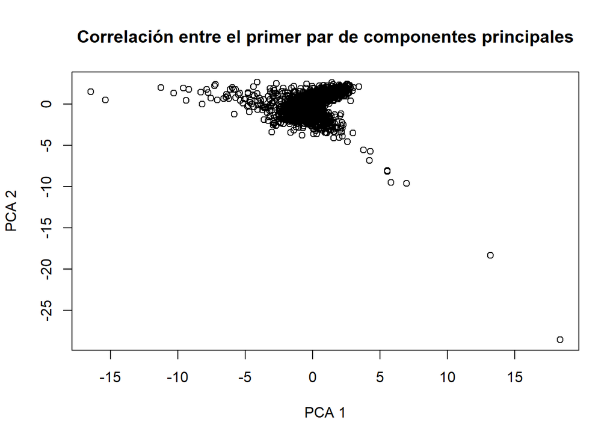

Seguidamente determinamos autovalores y autovectores para obtener un gráfico de barras para visualizar la variación porcentual por cada componente principal (Bar Scree Plot).

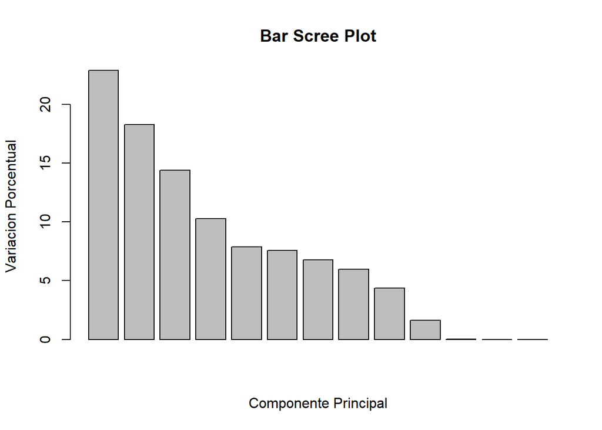

Determinamos las correlaciones entre el conjunto de datos original y las componentes principales:

[output not shown]

Nuevamente graficamos el *Scree Plot*, aunque en esta oportunidad con forma de líneas, con lo cual aplicamos la “Regla del codo” para elegir la cantidad de componentes para reducir el conjunto de datos en el que tan solo bastaría entre 4 o 5. Más de 5 ofrecerían menores rendimientos explicativos.

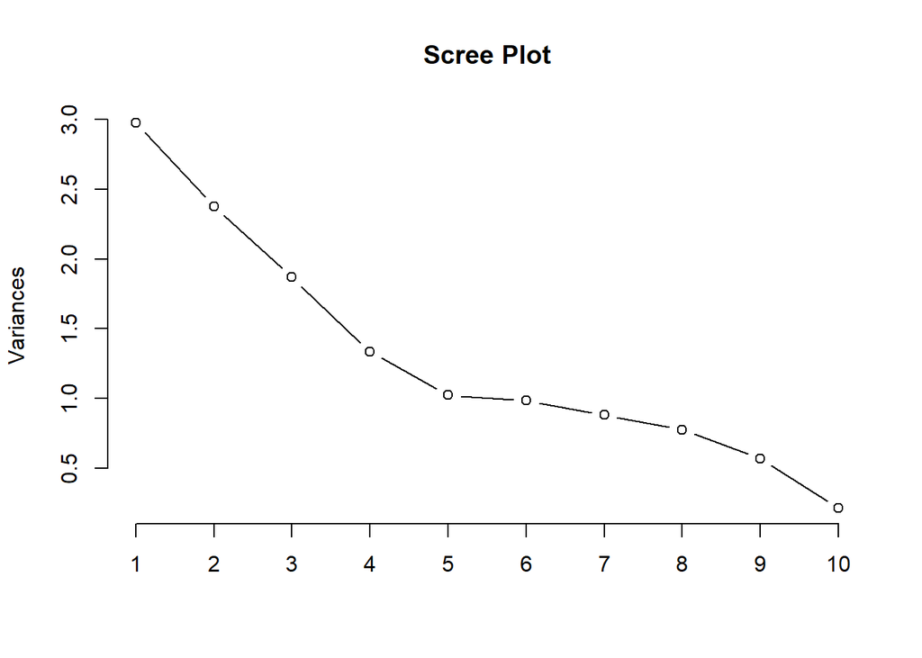